# Homework 05

Set a random seed before each simulation question and report it. You may use standard packages unless a question asks you to write the calculation yourself. Use equal neighbor weights throughout. Here $p$ counts the covariates used to measure distance; do not add an intercept column to a KNN predictor matrix. R and Python use different random-number generators, so their exact simulation results need not agree.

**Show the workflow**

```r
library(FNN)
library(glmnet)
```

**Show the workflow**

```r
library(MASS)
```

## Question 1: Estimate the bias and variance of KNN

In our previous homework, we used repeated simulations to study the behavior of linear regression estimators. We will now use the same idea for KNN. Consider the regression model

$$Y_i=f(\mathbf X_i)+\epsilon_i,
\qquad
f(\mathbf x)=0.5x_1+\sin(x_2)-0.3x_3^2,$$

where the three covariates are independent standard normal variables and $\epsilon_i\sim\mathcal N(0,0.1^2)$ independently of the covariates and other observations. Generate $n=400$ training observations. Our goal is to estimate the mean response at

$$\mathbf x_0=(0.5,0.7,1)^{\mathsf T}.$$

Use Euclidean distance and consider $k=1,3,5,\ldots,29$.

1. Calculate $f(\mathbf x_0)$. Generate one training dataset and obtain the KNN prediction at $\mathbf x_0$ for each value of $k$.
2. Independently repeat the generation of the training covariates and responses 200 times. Within each repetition, use the same training data for every value of $k$. Store the predictions in a matrix with 200 rows and one column for each value of $k$. Use this matrix to estimate the bias, variance, and mean squared error of the estimated mean response. Use divisor 200 when calculating the empirical variance, and verify numerically that

$$\text{mean squared error}
=\text{squared bias}+\text{variance}.$$

Plot squared bias, variance, and mean squared error against $k$ in one figure. Explain the pattern and compare it with the bias-variance trade-off for ridge regression or lasso.

## Solution to Problem 1

1a) The true mean response at the target point is f(x0) = 0.5(0.5) + sin(0.7) - 0.3(1)^2, which is about 0.594.

**Show the workflow**

```r
f <- function(X) 0.5 * X[, 1] + sin(X[, 2]) - 0.3 * X[, 3]^2
x0 <- c(0.5, 0.7, 1)
f0 <- 0.5 * x0[1] + sin(x0[2]) - 0.3 * x0[3]^2
ks <- seq(1, 29, by = 2)

gen1 <- function(n) {
  X <- matrix(rnorm(n * 3), n, 3)
  list(X = X, y = f(X) + rnorm(n, 0, 0.1))
}

set.seed(432)
d <- gen1(400)
pred_one <- sapply(ks, function(k) knn.reg(d$X, matrix(x0, 1), d$y, k = k)$pred)
f0
```

```
[1] 0.5942177
```

**Show the workflow**

```r
data.frame(k = ks, prediction = round(pred_one, 4))
```

```
    k prediction
1   1     0.7520
2   3     0.7520
3   5     0.5437
4   7     0.4586
5   9     0.4823
6  11     0.4087
7  13     0.4541
8  15     0.5077
9  17     0.5448
10 19     0.5171
11 21     0.4975
12 23     0.5478
13 25     0.5455
14 27     0.4762
15 29     0.4563
```

1b)

**Show the workflow**

```r
set.seed(433)
B <- 200
P <- matrix(NA, B, length(ks))
for (r in 1:B) {
  d <- gen1(400)
  P[r, ] <- sapply(ks, function(k) knn.reg(d$X, matrix(x0, 1), d$y, k = k)$pred)
}

bias <- colMeans(P) - f0
variance <- colMeans((P - matrix(colMeans(P), B, length(ks), byrow = TRUE))^2)
mse <- colMeans((P - f0)^2)

res1 <- data.frame(k = ks, sq_bias = bias^2, variance = variance, mse = mse)
round(res1, 5)
```

```
    k sq_bias variance     mse
1   1 0.00000  0.04073 0.04074
2   3 0.00052  0.02254 0.02305
3   5 0.00111  0.01454 0.01565
4   7 0.00167  0.01038 0.01205
5   9 0.00280  0.00982 0.01262
6  11 0.00378  0.00925 0.01303
7  13 0.00518  0.00798 0.01316
8  15 0.00686  0.00735 0.01421
9  17 0.00867  0.00733 0.01600
10 19 0.00891  0.00723 0.01614
11 21 0.01070  0.00695 0.01765
12 23 0.01188  0.00695 0.01882
13 25 0.01305  0.00596 0.01901
14 27 0.01368  0.00574 0.01941
15 29 0.01538  0.00558 0.02096
```

**Show the workflow**

```r
max(abs(res1$mse - (res1$sq_bias + res1$variance)))
```

```
[1] 1.040834e-17
```

**Show the workflow**

```r
all.equal(res1$mse, res1$sq_bias + res1$variance)
```

```
[1] TRUE
```

**Show the workflow**

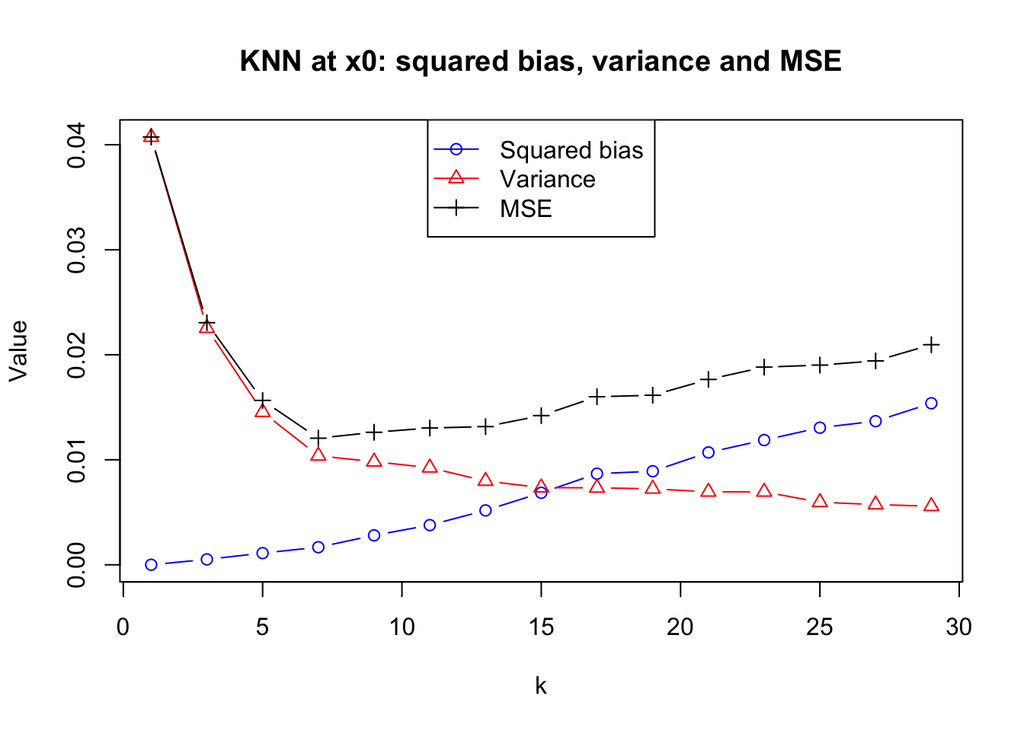

```r
matplot(ks, res1[, c("sq_bias", "variance", "mse")], type = "b", pch = 1:3,
        lty = 1, col = c("blue", "red", "black"), xlab = "k",
        ylab = "Value", main = "KNN at x0: squared bias, variance and MSE")
legend("top", c("Squared bias", "Variance", "MSE"), col = c("blue", "red", "black"),
       pch = 1:3, lty = 1)
```

The squared bias increases as k grows, while the variance decreases. Small k has low bias but high variance because predictions depend on only a few points. Large k reduces variance by averaging more points but increases bias because it includes points farther from x0. The MSE is the sum of squared bias and variance. It reaches a minimum of about 0.012 at k=7, showing that an intermediate k gives the best balance. The numerical check confirms that MSE = squared bias + variance, up to rounding error.

This is similar to ridge regression and lasso: increasing the tuning parameter increases bias and reduces variance, while decreasing it does the opposite. In all three methods, an intermediate value balances the two. Ridge and lasso control complexity by shrinking coefficients, while KNN does so by changing the number of neighbors used.

## Question 2: Compare KNN with lasso

Use the response model from Question 1, including the noise standard deviation $0.1$, but generate $p=30$ covariates. The response still depends only on the first three. Consider these two settings:

- **Setting 1:** all 30 covariates are independent standard normal variables.
- **Setting 2:** the covariates have a multivariate normal distribution with mean zero and covariance matrix $\boldsymbol\Sigma$, where

  $$\Sigma_{jj}=1,
  \qquad
  \Sigma_{jl}=0.8\quad\text{for }j\ne l.$$

In each setting, generate 400 training observations and 1,000 independent test observations. Fit 5NN using Euclidean distance on the supplied covariate scale. All covariates already have population variance one.

For lasso, use a linear model containing the 30 covariates and a separately fitted, unpenalized intercept. Follow the Week 4 objective,

$$L_\lambda(\boldsymbol\beta)
=\frac{1}{2n}\left\lVert
\widetilde{\mathbf y}-\mathbf X\boldsymbol\beta
\right\rVert_2^2
+\lambda\lVert\boldsymbol\beta\rVert_1,$$

where $\mathbf X\in\mathbb R^{n\times30}$ contains the centered and standardized covariates and $\widetilde{\mathbf y}$ is the centered training response. Select the penalty by ten-fold cross-validation over 41 logarithmically spaced values from $10^{-4}$ to $1$. Estimate all means and scales using only the training portion of each fold, with divisor equal to that portion’s sample size. After selecting the penalty, refit on all training observations and apply the fitted transformations unchanged to the test observations. Do not add nonlinear terms to the lasso model.

1. Fit both methods in each setting. Use the same training and test data for the two methods within a setting. Report their test MSE values in one table, together with the selected lasso penalty and the number of nonzero lasso slopes. You only need to generate one dataset for each setting; repeated simulations are not required.
2. Compare the results between the two settings. Explain how correlation can change the usefulness of Euclidean neighborhoods, and why lasso does not use all covariates in the same way as KNN.
3. The response model contains $\sin(X_2)$ and $X_3^2$, but the lasso fit uses only linear terms. Explain how this difference affects the comparison. Would the results justify a general claim that correlation always helps KNN, or that one method is always better? Explain why.

## Solution to Problem 2

**Show the workflow**

```r
set.seed(2)
p <- 30
lams <- 10^seq(-4, 0, length.out = 41)

prep <- function(X, y) {
  mu <- colMeans(X)
  s <- sqrt(colMeans(sweep(X, 2, mu)^2))       # divisor n
  list(mu = mu, s = s, ym = mean(y),
       Z = sweep(sweep(X, 2, mu), 2, s, "/"), yc = y - mean(y))
}
apply_prep <- function(pr, X) sweep(sweep(X, 2, pr$mu), 2, pr$s, "/")

run_setting <- function(Sigma = NULL) {
  gen2 <- function(n) {
    X <- if (is.null(Sigma)) matrix(rnorm(n * p), n, p) else mvrnorm(n, rep(0, p), Sigma)
    list(X = X, y = f(X[, 1:3]) + rnorm(n, 0, 0.1))
  }
  tr <- gen2(400)
  te <- gen2(1000)

  knn_mse <- mean((te$y - knn.reg(tr$X, te$X, tr$y, k = 5)$pred)^2)

  folds <- sample(rep(1:10, length.out = 400))
  cv <- matrix(NA, 10, length(lams))
  for (j in 1:10) {
    a <- tr$X[folds != j, ]; ya <- tr$y[folds != j]
    b <- tr$X[folds == j, ]; yb <- tr$y[folds == j]
    pr <- prep(a, ya)
    g <- glmnet(pr$Z, pr$yc, lambda = rev(lams), standardize = FALSE, intercept = FALSE)
    B <- as.matrix(coef(g, s = lams))[-1, ]
    fitted <- apply_prep(pr, b) %*% B + pr$ym
    cv[j, ] <- colMeans((yb - fitted)^2)
  }
  lam <- lams[which.min(colMeans(cv))]

  pr <- prep(tr$X, tr$y)
  g <- glmnet(pr$Z, pr$yc, lambda = rev(lams), standardize = FALSE, intercept = FALSE)
  beta <- as.numeric(coef(g, s = lam))[-1]
  lasso_mse <- mean((te$y - (apply_prep(pr, te$X) %*% beta + pr$ym))^2)

  data.frame(KNN5_test_MSE = knn_mse, Lasso_test_MSE = lasso_mse,
             lasso_lambda = lam, nonzero_slopes = sum(beta != 0))
}

Sigma2 <- matrix(0.8, p, p); diag(Sigma2) <- 1
tab2 <- rbind("Setting 1: independent" = run_setting(NULL),
              "Setting 2: correlation 0.8" = run_setting(Sigma2))
tab2
```

```
                           KNN5_test_MSE Lasso_test_MSE lasso_lambda
Setting 1: independent         0.5256686      0.2451963   0.03981072
Setting 2: correlation 0.8     0.1771559      0.3298990   0.01995262
                           nonzero_slopes
Setting 1: independent                  2
Setting 2: correlation 0.8              5
```

1. Setting 1: 5NN MSE = 0.526; lasso MSE = 0.245, penalty = 0.040, 2 nonzero slopes.Setting 2: 5NN MSE = 0.177; lasso MSE = 0.330, penalty = 0.020, 5 nonzero slopes.
2. Lasso performed better with independent covariates, while KNN performed better with correlated covariates. KNN uses all 30 variables to calculate distances, so irrelevant variables add noise when covariates are independent. Correlation reduces the effective dimension, making neighborhoods more useful. Lasso can eliminate irrelevant variables, but high correlation makes variable selection harder and can increase its test error.
3. Lasso uses only linear terms, so it cannot fully capture the nonlinear terms sin(X2) and X3^2. KNN can capture nonlinear relationships but is affected by irrelevant variables in distance calculations.These results do not show that correlation always helps KNN or that one method is always better. They come from just one dataset per setting and depend on the specific sample size, correlation structure, and response function.

## Question 3: Observed dimension and latent dimension

The lecture’s handwritten digit example shows that KNN can work with many measured covariates. We will use a simulation to investigate why the structure of those covariates matters.

Let $p=100$ be the number of observed covariates and let $m$ be the number of latent variables. For each observation, generate

$$\mathbf X_i=\mathbf A\mathbf Z_i+\boldsymbol\eta_i,
\qquad
Y_i=Z_{i1}+Z_{i2}+\epsilon_i,$$

where $\mathbf A\in\mathbb R^{100\times m}$ has independent entries from Uniform$[-2,2]$. The entries of $\mathbf Z_i\in\mathbb R^m$ and $\boldsymbol\eta_i\in\mathbb R^{100}$, and the scalar $\epsilon_i$, are independent standard normal variables, also independent of $\mathbf A$. Generate $\mathbf A$ once and use it for all training and test observations in that dataset.

Compare $m=3$ and $m=30$. In each setting, generate 200 training observations and 200 independent test observations. Fit KNN using only the 100 observed covariates in $\mathbf X$, with Euclidean distance on their generated scale. The latent variables in $\mathbf Z$ are used to generate the data but are not available to the fitted model. Consider $k=2,10,18,\ldots,82$.

1. Generate one dataset for each value of $m$. Fit KNN for every value of $k$ and calculate test MSE. Within a setting, use the same training and test observations for all values of $k$.
2. Repeat the complete experiment 50 times, generating a new $\mathbf A$ and new observations in each repetition. Plot average test MSE against $k$, with one curve for each value of $m$. These curves compare the specified choices of $k$ in a controlled simulation; they are not a cross-validation procedure for selecting a final model.
3. Both settings have 100 observed covariates, and the response depends on only two latent variables. Explain why their KNN performance can still differ. What role does the noise $\boldsymbol\eta_i$ play, and why are the observed data not confined exactly to an $m$-dimensional linear space?

## Solution to Problem 3

1. and b) The function below performs one dataset for a given m, and the experiment is then repeated 50 times with a new A and new data each time. The seed is 3.

**Show the workflow**

```r
set.seed(3)
ks3 <- seq(2, 82, by = 8)

one_run <- function(m) {
  A <- matrix(runif(100 * m, -2, 2), 100, m)
  gen3 <- function(n) {
    Z <- matrix(rnorm(n * m), n, m)
    X <- Z %*% t(A) + matrix(rnorm(n * 100), n, 100)
    list(X = X, y = Z[, 1] + Z[, 2] + rnorm(n))
  }
  tr <- gen3(200)
  te <- gen3(200)
  sapply(ks3, function(k) mean((te$y - knn.reg(tr$X, te$X, tr$y, k = k)$pred)^2))
}

part_a <- rbind("m = 3" = one_run(3), "m = 30" = one_run(30))
colnames(part_a) <- paste0("k=", ks3)
round(part_a, 3)
```

```
         k=2  k=10  k=18  k=26  k=34  k=42  k=50  k=58  k=66  k=74  k=82
m = 3  1.719 1.306 1.300 1.355 1.390 1.460 1.528 1.594 1.649 1.724 1.804
m = 30 3.074 2.515 2.469 2.455 2.449 2.536 2.537 2.550 2.556 2.576 2.612
```

**Show the workflow**

```r
R <- 50
M3 <- M30 <- matrix(NA, R, length(ks3))
for (r in 1:R) {
  M3[r, ] <- one_run(3)
  M30[r, ] <- one_run(30)
}
avg <- data.frame(k = ks3, m3 = colMeans(M3), m30 = colMeans(M30))
round(avg, 3)
```

```
    k    m3   m30
1   2 1.701 3.000
2  10 1.270 2.335
3  18 1.298 2.327
4  26 1.342 2.348
5  34 1.393 2.376
6  42 1.453 2.406
7  50 1.513 2.437
8  58 1.572 2.471
9  66 1.630 2.503
10 74 1.691 2.528
11 82 1.750 2.553
```

**Show the workflow**

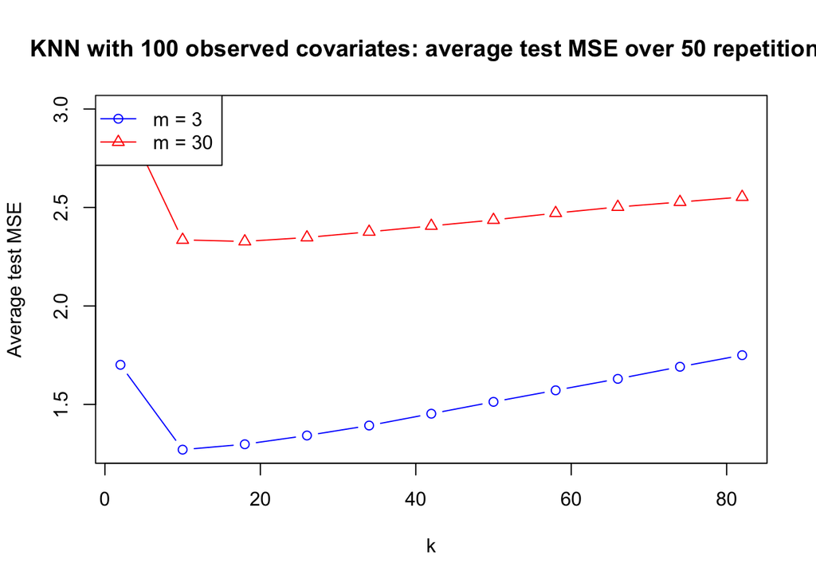

```r
matplot(ks3, avg[, c("m3", "m30")], type = "b", pch = 1:2, lty = 1,
        col = c("blue", "red"), xlab = "k", ylab = "Average test MSE",
        main = "KNN with 100 observed covariates: average test MSE over 50 repetitions")
legend("topleft", c("m = 3", "m = 30"), col = c("blue", "red"), pch = 1:2, lty = 1)
```

1. and b) The average test MSE is lower for m = 3 than for m = 30 at every k. For m = 3, the minimum is about 1.27 at k = 10, compared to 2.33 at k = 18 for m = 30. Both curves rise at larger k, while k = 2 has high error due to high variance. The overall mean predictor has a test MSE of about 3, so KNN performs much better for m = 3.
2. Although both settings have 100 observed covariates and only two relevant latent variables, their KNN performance differs because of the intrinsic dimension m. When m = 3, most variation in the observed data is related to the response, so nearby points tend to have similar responses. When m = 30, many directions add irrelevant variation, making neighbors less similar and increasing test error. The noise eta adds independent variation to all 100 observed covariates, scattering the data around the m-dimensional signal space. Thus, the observations are not confined exactly to that space, and the noise makes distances less informative about the relevant latent variables.

## Question 4: Classify handwritten digits

Use `zip.train` and `zip.test` from the R package `ElemStatLearn`, as in the lecture. The package has been retired from the active CRAN repository. If needed, install the [archived package](https://cran.r-project.org/src/contrib/Archive/ElemStatLearn/ElemStatLearn_2015.6.26.2.tar.gz) into your usual R library, then load the two datasets. Python users can use the course copies of the same [training data](https://teazrq.github.io/stat432rpy/data/knn/zip-train.csv.gz) and [test data](https://teazrq.github.io/stat432rpy/data/knn/zip-test.csv.gz). These compressed CSV files have no headers and are included in the homework ZIP under `data/knn`. Run the Python code from the folder containing `data`.

Each image has $16\times16=256$ pixel values. The first column is the digit label and the remaining columns are the pixel values. Use the first 1,000 rows of `zip.train` and the first 500 rows of `zip.test`. Use the original pixel values without standardization, and do not include the digit label in a distance calculation.

For a test image $\mathbf x_0$ and a training image $\mathbf x_i$, the two distances are

$$d_E(\mathbf x_0,\mathbf x_i)
=\sqrt{\sum_{j=1}^{256}(x_{0j}-x_{ij})^2},
\qquad
d_M(\mathbf x_0,\mathbf x_i)
=\sum_{j=1}^{256}|x_{0j}-x_{ij}|.$$

1. Write a 5NN classification function that allows either Euclidean or Manhattan distance. For each test image, calculate its distances to the training images directly, find the five nearest, and return the most frequent digit label. Break distance ties by the smaller training row number and voting ties by the smallest digit. Do not use a built-in distance or KNN function for this part.
2. Apply the classifier to all 500 test images using each distance. For each fit, report the test classification error and a $10\times10$ confusion matrix, with rows representing predicted digits and columns representing true digits. Keep all digit labels from 0 through 9 in the matrix, including any with a zero count. Which digits are most often confused with one another?
3. For Euclidean distance, display three incorrectly classified test images, together with their true and predicted labels. Comment on whether the mistakes are visually understandable. Compare the overall results of the two distance measures. Can they have similar total error while making mistakes on different images? Use your predictions to support your answer.

## Solution to Problem 4

**Show the workflow**

```r
library(ElemStatLearn)
data(zip.train)
data(zip.test)

train <- zip.train[1:1000, ]
test <- zip.test[1:500, ]
Xtr <- train[, -1]; ytr <- train[, 1]
Xte <- test[, -1]; yte <- test[, 1]
dim(Xtr); dim(Xte)
```

```
[1] 1000  256
```

```
[1] 500 256
```

1. The classifier computes the distances by hand, orders them with ties broken by the smaller training row number, takes the five nearest, and returns the most frequent label, with vote ties going to the smallest digit.

**Show the workflow**

```r
knn5 <- function(Xtrain, ytrain, Xtest, k = 5, dist = c("euclidean", "manhattan")) {
  dist <- match.arg(dist)
  pred <- integer(nrow(Xtest))
  for (i in seq_len(nrow(Xtest))) {
    diffs <- sweep(Xtrain, 2, Xtest[i, ], "-")
    d <- if (dist == "euclidean") sqrt(rowSums(diffs^2)) else rowSums(abs(diffs))
    nn <- order(d, seq_along(d))[1:k]          # ties: smaller training row first
    votes <- tabulate(ytrain[nn] + 1, nbins = 10)
    pred[i] <- which.max(votes) - 1            # ties: smallest digit
  }
  pred
}
```

2. Both distances are applied to all 500 test images. The confusion matrices have predicted digits in rows and true digits in columns, and all ten labels are kept.

**Show the workflow**

```r
pred_E <- knn5(Xtr, ytr, Xte, dist = "euclidean")
pred_M <- knn5(Xtr, ytr, Xte, dist = "manhattan")

err_E <- mean(pred_E != yte)
err_M <- mean(pred_M != yte)
c(euclidean = err_E, manhattan = err_M)
```

```
euclidean manhattan
    0.122     0.138
```

**Show the workflow**

```r
cm_E <- table(Predicted = factor(pred_E, levels = 0:9), True = factor(yte, levels = 0:9))
cm_M <- table(Predicted = factor(pred_M, levels = 0:9), True = factor(yte, levels = 0:9))
cm_E
```

```
         True
Predicted   0   1   2   3   4   5   6   7   8   9
        0 118   0   7   1   0   4   2   0   2   0
        1   0  66   0   0   2   0   0   0   0   1
        2   0   0  39   1   0   0   2   0   0   1
        3   0   0   0  23   0   4   0   0   2   0
        4   0   0   1   0  27   1   1   1   0   1
        5   0   0   0   1   0  13   0   0   0   0
        6   0   2   0   0   0   1  41   0   2   0
        7   0   0   0   0   1   1   0  34   0   4
        8   0   0   3   2   0   2   0   0  37   0
        9   1   0   0   1   4   0   0   1   1  41
```

**Show the workflow**

```r
cm_M
```

```
         True
Predicted   0   1   2   3   4   5   6   7   8   9
        0 118   0   6   1   0   5   3   0   4   0
        1   0  67   2   0   2   0   1   0   0   1
        2   0   0  35   0   0   0   2   0   0   0
        3   0   0   1  24   0   4   0   0   2   0
        4   0   0   1   1  27   1   0   1   0   1
        5   0   0   0   1   0  11   0   0   0   0
        6   0   1   0   0   0   2  40   0   2   0
        7   0   0   2   1   1   0   0  34   0   5
        8   0   0   2   0   0   3   0   0  34   0
        9   1   0   1   1   4   0   0   1   2  41
```

**Show the workflow**

```r
top_conf <- function(cm, n = 5) {
  off <- as.data.frame(cm)
  off <- off[off$Predicted != off$True & off$Freq > 0, ]
  head(off[order(-off$Freq), ], n)
}
top_conf(cm_E)
```

```
   Predicted True Freq
21         0    2    7
50         9    4    4
51         0    5    4
54         3    5    4
98         7    9    4
```

**Show the workflow**

```r
top_conf(cm_M)
```

```
   Predicted True Freq
21         0    2    6
51         0    5    5
98         7    9    5
50         9    4    4
54         3    5    4
```

**Show the workflow**

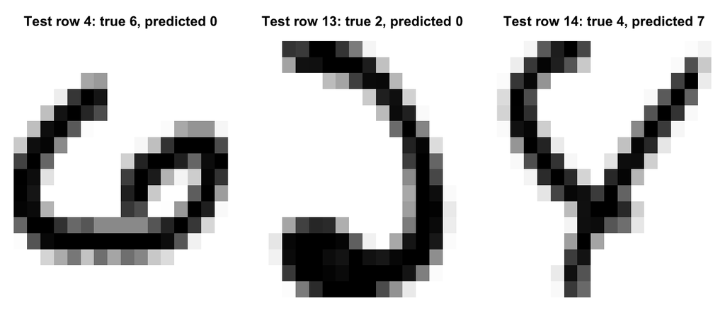

```r
wrong_E <- which(pred_E != yte)
show <- head(wrong_E, 3)

par(mfrow = c(1, 3), mar = c(1, 1, 3, 1))
for (i in show) {
  m <- matrix(Xte[i, ], 16, 16, byrow = TRUE)
  image(t(m)[, 16:1], col = gray(seq(1, 0, length.out = 256)), axes = FALSE,
        main = paste0("Test row ", i, ": true ", yte[i], ", predicted ", pred_E[i]))
}
```

**Show the workflow**

```r
par(mfrow = c(1, 1))

wrong_M <- which(pred_M != yte)
length(wrong_E); length(wrong_M)
```

```
[1] 61
```

```
[1] 69
```

**Show the workflow**

```r
length(intersect(wrong_E, wrong_M))
```

```
[1] 58
```

**Show the workflow**

```r
length(setdiff(wrong_E, wrong_M))
```

```
[1] 3
```

**Show the workflow**

```r
length(setdiff(wrong_M, wrong_E))
```

```
[1] 11
```

**Show the workflow**

```r
sum(pred_E != pred_M)
```

```
[1] 22
```

3. Misclassified digits are often messy, slanted, or resemble another digit, making them difficult to identify. Some may also have unusual writing styles that are not represented in the training data.

## Question 5: Create a plot-formatting skill

Create a short `SKILL.md` file for improving the formatting of STAT 432 homework plots. You may use AI to help write it.

1. Include a title, a description, and a few formatting rules. The description should limit the skill to STAT 432 homework plot improvements and require an explicit request to use it. Your rules should address margins, titles, axes, labels, colors, and sizes for plots produced in R or Python. Keep them portable: do not refer to specific homework questions.
2. Ask your agent to install the skill. Explicitly call it to improve the plot from Question 1, then compare the original and revised versions. Do you like the changes? You may revise the skill and test it a couple more times, or uninstall it if it remains unhelpful.
3. Append your final `SKILL.md` content to your submission and briefly explain your choices and experience.

## Question 5 - Content for SKILL.md

name: plot-skill description: This skill improves the formatting and readability of plots made in R or Python for STAT 432 homework. Use it only when the user explicitly asks to apply this skill; otherwise, leave plot formatting unchanged unless requested.

Formatting Rules - **Margins:** Use balanced margins so titles, axis labels, tick labels, and legends are not clipped or crowded. - **Titles:** Add a concise, descriptive title when appropriate. Keep it readable and visually distinct without overpowering the plot. - **Axes:** Use clear axis titles with units when relevant. Choose sensible limits and readable tick marks; avoid unnecessary visual clutter. - **Labels:** Use meaningful labels and consistent notation. Ensure tick labels, legends, and annotations are legible and do not overlap. - **Colors:** Use a restrained, accessible palette with sufficient contrast. Avoid relying on color alone to distinguish groups when other cues are practical. - **Sizes:** Set plot dimensions and font sizes for the intended output (such as a homework PDF or report). Keep text readable and line widths/point sizes proportionate. - **Consistency:** Apply a consistent visual style across related plots, while preserving the data and the statistical meaning.

Explanation: I chose to keep the skill short but detailed to not specifiy too much and keep it general for all types of questions. Things like margins, titles, and axes will be consistent across many plots we create so there are guidelines for those. After recreating the plots from question 1, I didn’t notice too much an improvement change in the plots, both of them looked nice before and after. However, having this skill is helpful to keep plots consistent looking across all assingments and problems.